# ggplot2 examples and exercises

### Annotation

Text is a huge part of storytelling with your visualisation. Historically, textual annotations has not been the best part of ggplot2 but new extensions make up for that.

Standard geom_text will often result in overlaping labels

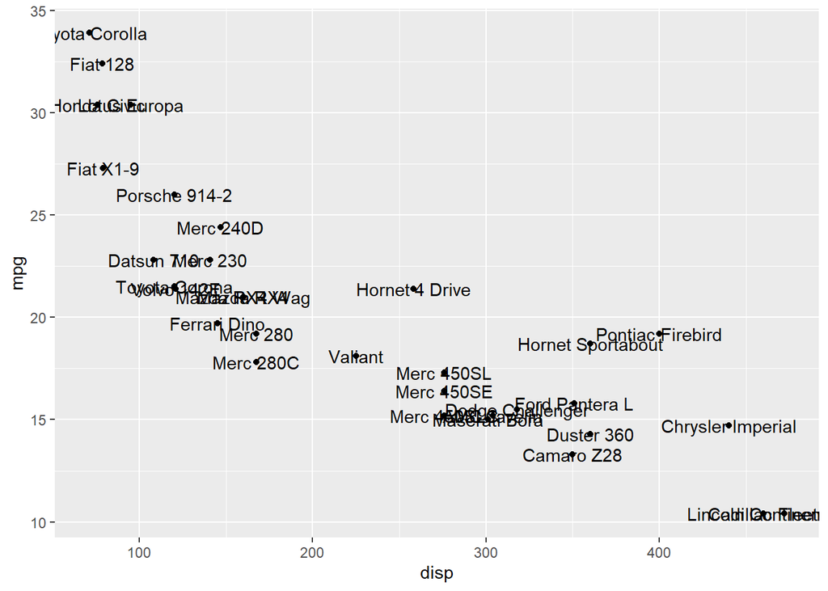

```r
ggplot(mtcars, aes(x = disp, y = mpg)) +
  geom_point() +
  geom_text(aes(label = row.names(mtcars)))
```

ggrepel takes care of that

```r
library(ggrepel)
```

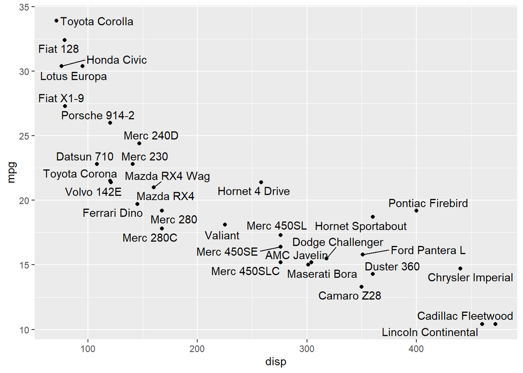

```r
ggplot(mtcars, aes(x = disp, y = mpg)) +
  geom_point() +
  geom_text_repel(aes(label = row.names(mtcars)))
```

If you want to highlight certain parts of your data and describe it, the `geom_mark_*()` family of geoms have your back

```r
library(ggforce)
```

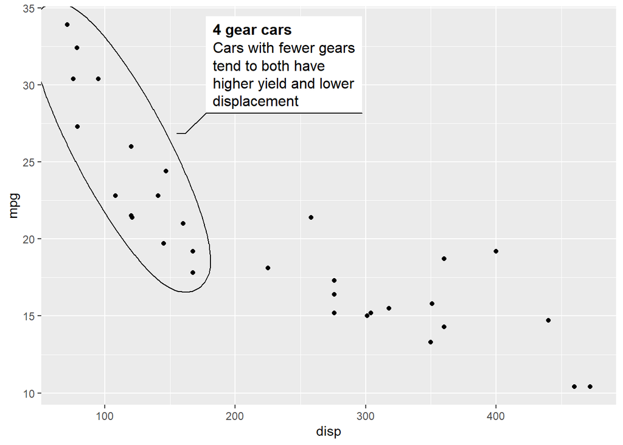

```r
ggplot(mtcars, aes(x = disp, y = mpg)) +
  geom_point() +
  geom_mark_ellipse(aes(filter = gear == 4,
                        label = '4 gear cars',
                        description = 'Cars with fewer gears tend to both have higher yield and lower displacement'))
```

#### Exercises

ggrepel has a tonne of settings for controlling how text labels move. Often, though, the most effective is simply to not label everything. There are two strategies for that: Either only use a subset of the data for the repel layer, or setting the label to `""` for those you don’t want to plot. Try both in the plot below where you only label 10 random points.

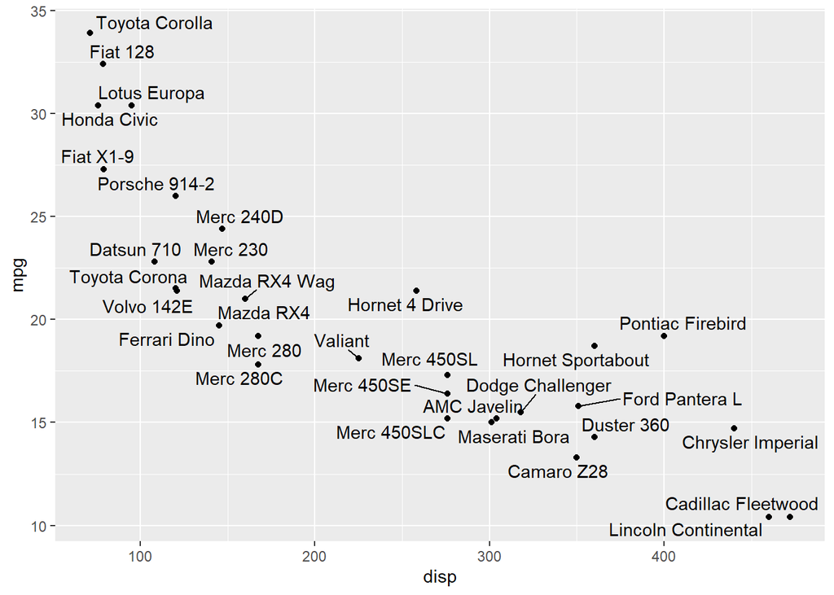

```r
mtcars2 <- mtcars
mtcars2$label <- rownames(mtcars2)
points_to_label <- sample(nrow(mtcars), 10)
ggplot(mtcars2, aes(x = disp, y = mpg)) +
  geom_point() +
  geom_text_repel(aes(label = label))
```

Explore the documentation for `geom_text_repel`. Find a way to ensure that the labels in the plot below only repels in the vertical direction

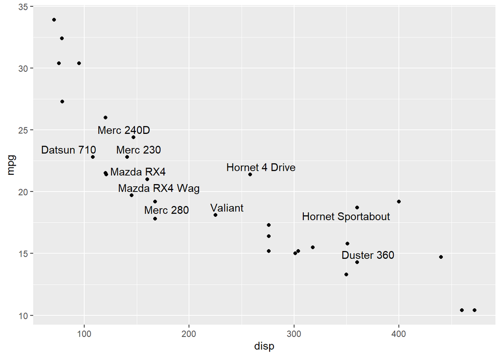

```r
mtcars2$label <- ""
mtcars2$label[1:10] <- rownames(mtcars2)[1:10]
ggplot(mtcars2, aes(x = disp, y = mpg)) +
  geom_point() +
  geom_text_repel(aes(label = label))
```

ggforce comes with 4 different types of mark geoms. Try them all out in the code below:

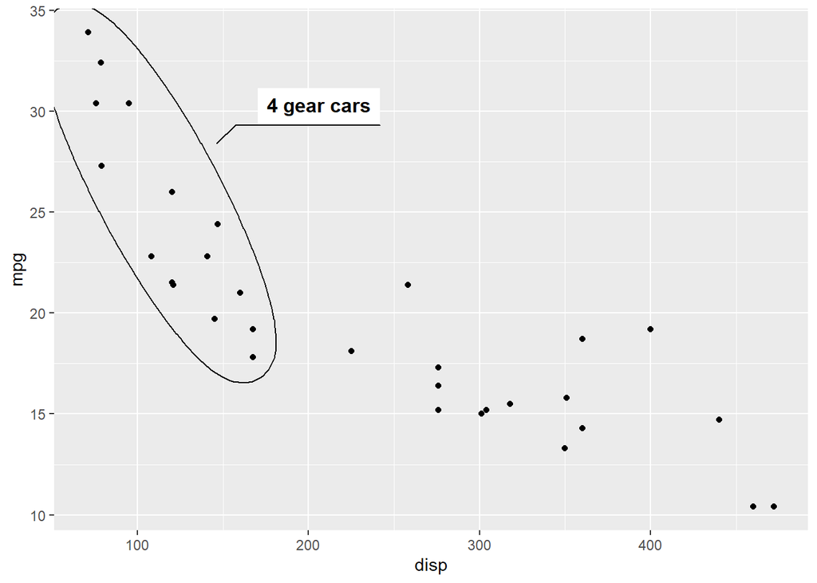

```r
ggplot(mtcars, aes(x = disp, y = mpg)) +
  geom_point() +
  geom_mark_ellipse(aes(filter = gear == 4,
                        label = '4 gear cars'))
```

### Networks

ggplot2 has been focused on tabular data. Network data in any shape and form is handled by ggraph

```
## Using `stress` as default layout
```

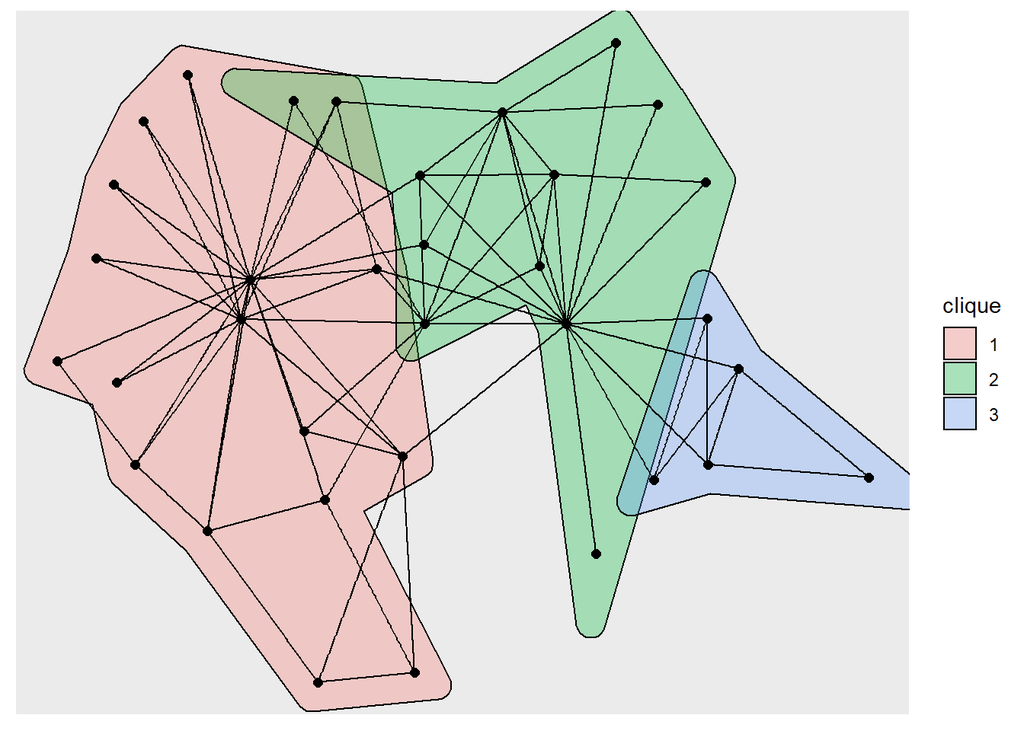

```r
library(ggraph)
library(tidygraph)
graph <- create_notable('zachary') %>%
  mutate(clique = as.factor(group_infomap()))
ggraph(graph) +
  geom_mark_hull(aes(x, y, fill = clique)) +
  geom_edge_link() +
  geom_node_point(size = 2)
```

dendrograms are just a specific type of network

```
## Using `dendrogram` as default layout
```

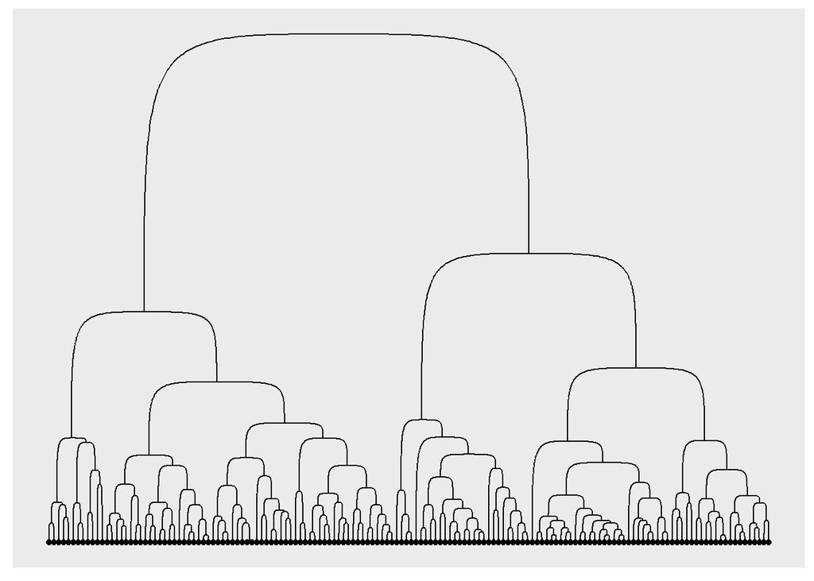

```r
iris_clust <- hclust(dist(iris[, 1:4]))
ggraph(iris_clust) +
  geom_edge_bend() +
  geom_node_point(aes(filter = leaf))
```

#### Exercies

Most network plots are defined by a layout algorithm, which takes the network structure and calculate a position for each node. The layout algorithm is global and set in the `ggraph()`. The default `auto` layout will inspect the network object and try to choose a sensible layout for it (e.g. dendrogram for a hierarchical clustering as above). There is, however no optimal layout and it is often a good idea to try out different layouts. Try out different layouts in the graph below. See the [the website](https://ggraph.data-imaginist.com/reference/index.html) for an overview of the different layouts.

```
## Using `stress` as default layout
```

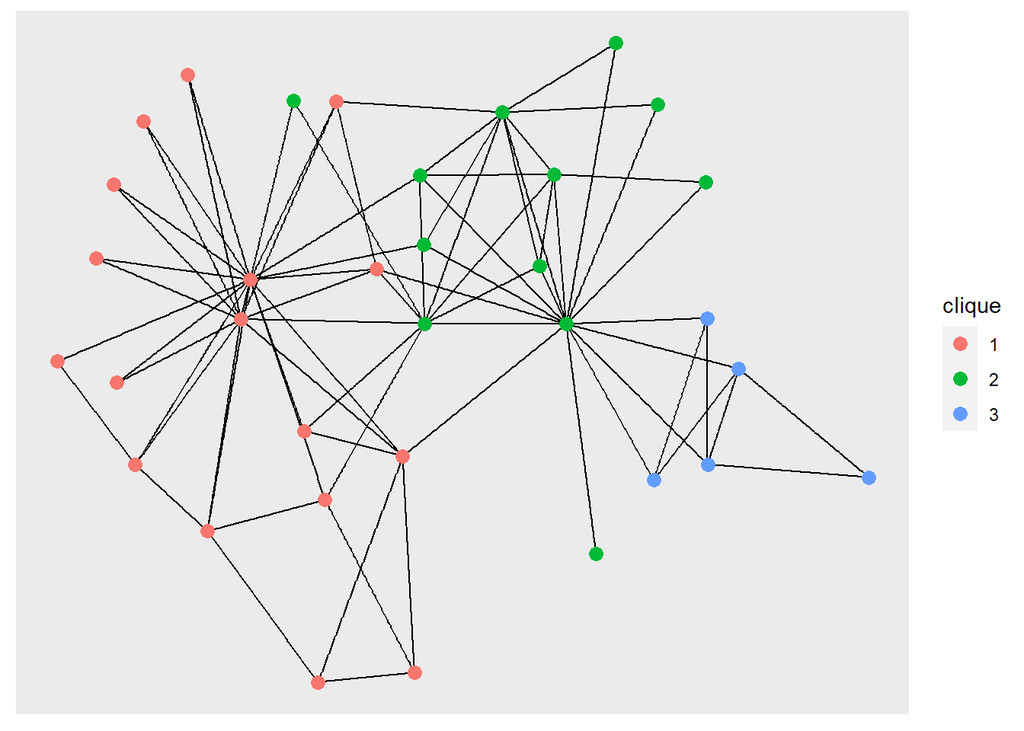

```r
ggraph(graph) +
  geom_edge_link() +
  geom_node_point(aes(colour = clique), size = 3)
```

There are many different ways to draw edges. Try to use `geom_edge_parallel()` in the graph below to show the presence of multiple edges

```
## Using `stress` as default layout
```

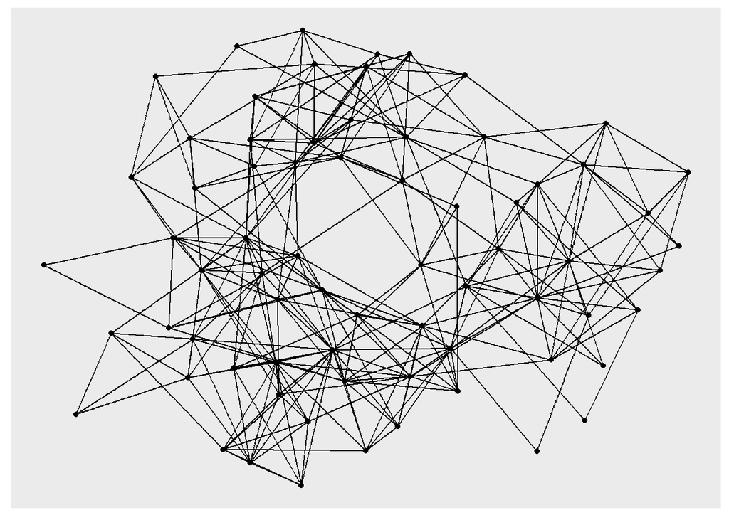

```r
highschool_gr <- as_tbl_graph(highschool)
ggraph(highschool_gr) +
  geom_edge_link() +
  geom_node_point()
```

Faceting works in ggraph as it does in ggplot2, but you must choose to facet by either nodes or edges. Modify the graph below to facet the edges by the `year` variable (using `facet_edges()`)

```
## Using `stress` as default layout
```

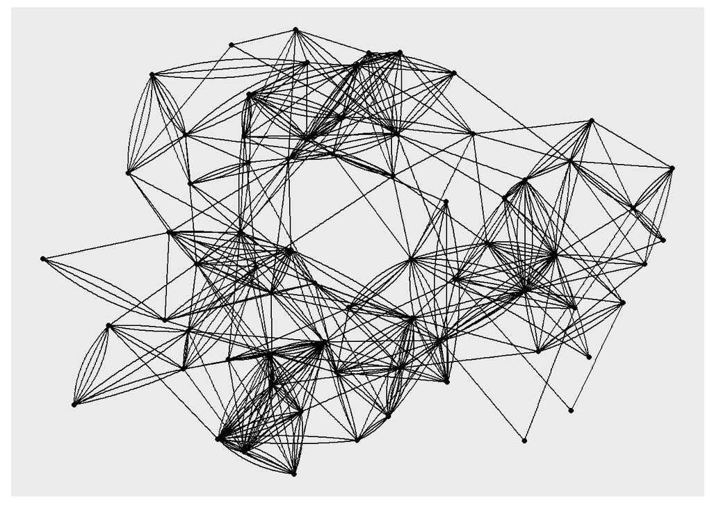

```r
ggraph(highschool_gr) +
  geom_edge_fan() +
  geom_node_point()
```

### Looks

Many people have already desgned beautiful (and horrible) themes for you. Use them as a base

[output not shown]

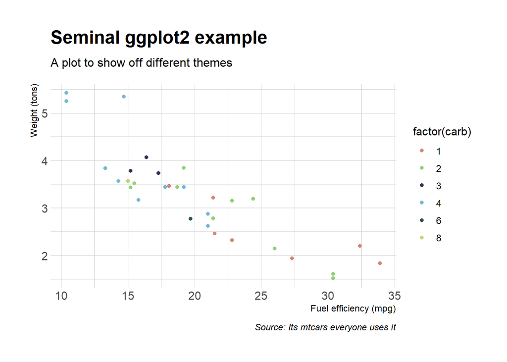

```r
p <- ggplot(mtcars, aes(mpg, wt)) +
  geom_point(aes(color = factor(carb))) +
  labs(
    x = 'Fuel efficiency (mpg)',
    y = 'Weight (tons)',
    title = 'Seminal ggplot2 example',
    subtitle = 'A plot to show off different themes',
    caption = 'Source: Its mtcars everyone uses it'
  )
library(hrbrthemes)
p +
  scale_colour_ipsum() +
  theme_ipsum()
```

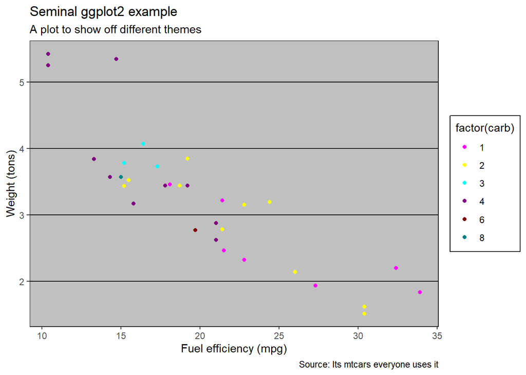

```r
library(ggthemes)
p +
  scale_colour_excel() +
  theme_excel()
```

## Drawing anything

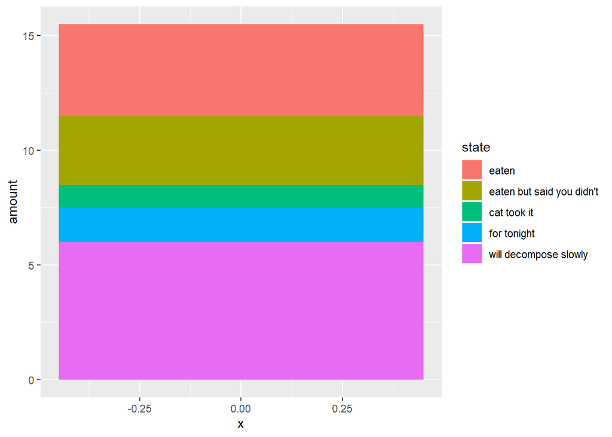

```r
states <- c(
  'eaten', "eaten but said you didn\'t", 'cat took it', 'for tonight',
  'will decompose slowly'
)
pie <- data.frame(
  state = factor(states, levels = states),
  amount = c(4, 3, 1, 1.5, 6),
  stringsAsFactors = FALSE
)
ggplot(pie) +
  geom_col(aes(x = 0, y = amount, fill = state))
```

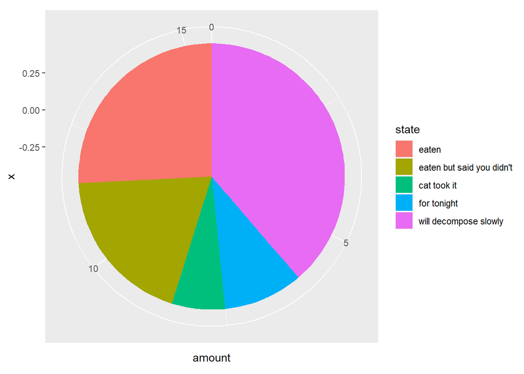

```r
ggplot(pie) +
  geom_col(aes(x = 0, y = amount, fill = state)) +
  coord_polar(theta = 'y')
```

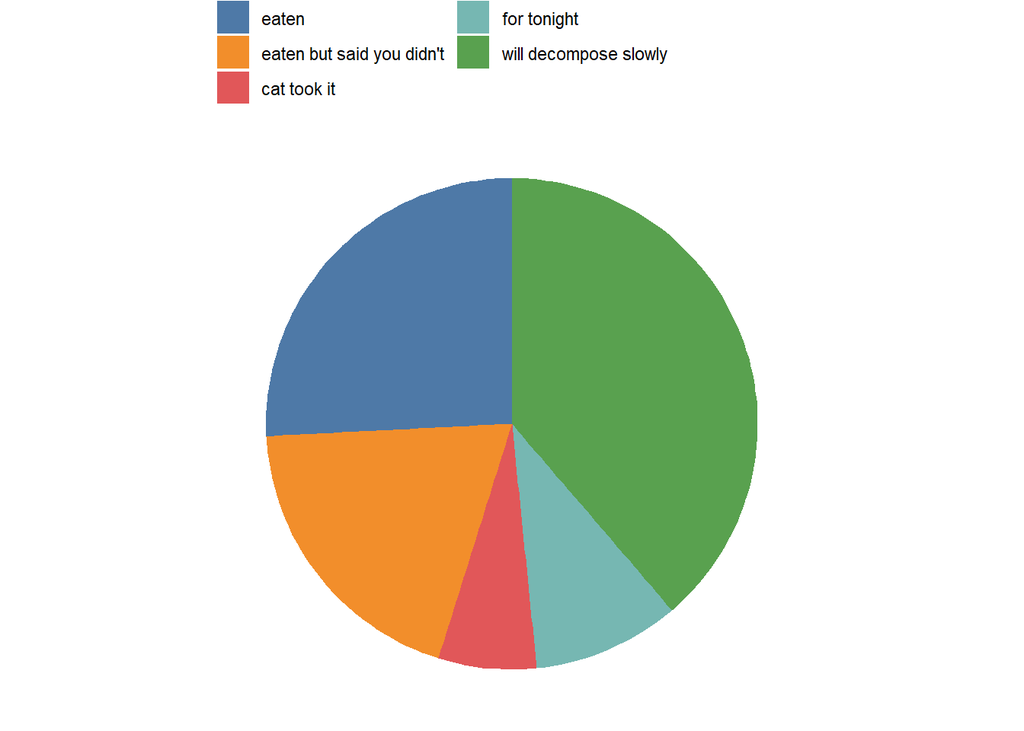

```r
ggplot(pie) +
  geom_col(aes(x = 0, y = amount, fill = state)) +
  coord_polar(theta = 'y') +
  scale_fill_tableau(name = NULL,
                     guide = guide_legend(ncol = 2)) +
  theme_void() +
  theme(legend.position = 'top',
        legend.justification = 'left')
```